# MeshInstance

# MeshInstances let you add 3D models to your games.

`Meshinstance` is the node for displaying meshes in a 3D scene.

A `MultiMeshInstance` helps render a large number of the same `Mesh` at a low cost to the renderer. It’s ideal for adding details and props to scenes and environments.

In this guide, you will learn how to:

- Set up and use a `MeshInstance` and `MultiMeshInstance`.
- Use a `MultiMeshInstance` to create a small forest.
- Set the motion of meshes in a `MultimeshInstance` to create a flock.
- Use shaders to apply a height map to a `PlaneMesh`.

Contents:

- Setting up a MeshInstance
  - Default properties
  - Using Godot’s built-in meshes
- Using a MeshInstance and MultiMeshInstance in practice
  - Creating a forest with a MultiMeshInstance
  - Creating flocking Boids behavior with a MultiMeshInstance with a script
  - Changing the shape of your Mesh with a vertex shader
- Pro tips
  - Generating collision bodies
  - Creating other resources from meshes
- Your questions
  - When should I use MultiMeshInstances instead of MeshInstances?

## Setting up a MeshInstance

### Default properties

`MeshInstance` has three properties that you can set. The *Mesh* property contains a `Mesh` resource. The *Skin* property is data for the bone bindings. The *Skeleton* property is the `NodePath` to a `Skeleton` node.

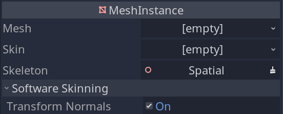

Each `MeshInstance` requires a nonempty *Mesh* property to be useful in the scene. Godot provides a set of simple meshes, including cubes, capsules, and planes. You may also load a custom mesh created in a 3D modeling program, such as [Blender](https://www.blender.org).

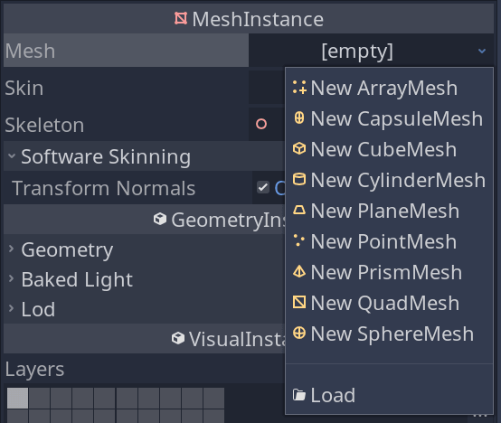

Godot generates the *Skin* value for built-in meshes like a cube or capsule. For imported meshes from 3D modeling software like Blender, Godot generates the *Skin* value if relevant.

When you import a rigged character or object, Godot detects its `Skeleton`. If Godot fails to find the `Skeleton`, or if you have a custom `Skeleton`, then set the *Skeleton* property.

[figure not shown]

### Using Godot’s built-in meshes

After selecting one of the built-in mesh resources, you can access more properties to customize it. Each built-in `Mesh` has a unique set of properties. For example, `CubeMesh` has a *Size* property, and `SphereMesh` has *Radius* and *Height* properties.

Many built-in meshes have properties to set the level of detail. Larger numbers make the shape more precise at the cost of performance.

- Round `Mesh` resources like the `SphereMesh`, `CapsuleMesh` and `CylinderMesh` have the *Radial Segments* and *Rings* properties.
- Cubic `Mesh` resources like the `CubeMesh` and `PrismMesh` have the *Subdivide Width*, *Subdivide Height* and *Subdivide Depth* properties.

Other properties controlling how Godot renders the `Mesh` include:

- *Flip Faces*, which causes the `Mesh` to render inside out. This property helps create a room interior from one cube.
- *Lightmap Size Hint*, which controls how Godot should calculate the lightmap from this `Mesh`.
- *Custom Aabb*, which defines where the renderer sees the `Mesh` for culling purposes.

You can set the *Material* property of the `Mesh` to either a `SpatialMaterial` or a `ShaderMaterial`. The *Material* property controls the appearance of your `Mesh`, including color, texture, or glossiness.

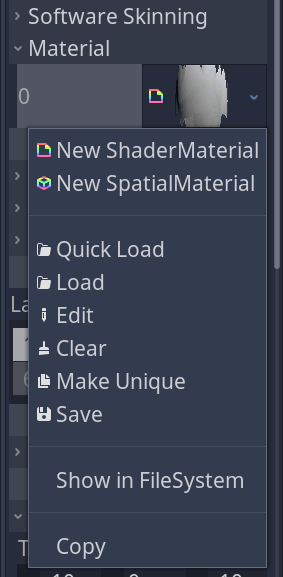

A `SpatialMaterial` lets you set up custom colors, surface textures, and more. The official Godot documentation has [an in-depth look at the settings of `SpatialMaterial`](https://docs.godotengine.org/en/stable/tutorials/3d/spatial_material.html).

For more fine-grained control over the `Mesh`, you can use a `ShaderMaterial`. Learning to use shaders gives you access to many effects, such as making running water, snow, and fog.

This guide covers a simple shader. You can [learn more about getting started with shaders](https://docs.godotengine.org/en/stable/tutorials/shaders/your_first_shader/your_first_3d_shader.html) in the Godot documentation or in our [Godot shader secrets course](https://gdquest.mavenseed.com/courses/godot-shader-secrets) .

## Using a MeshInstance and MultiMeshInstance in practice

There are many situations where it’s helpful to duplicate and randomly orient a mesh spread out over a given area.

Common examples include grassy fields, a backdrop of trees filling the horizon, or a skyline of buildings.

### Creating a forest with a MultiMeshInstance

In the section you will use a `MultiMeshInstance` node to make a forest without setting up each tree `Mesh` individually.

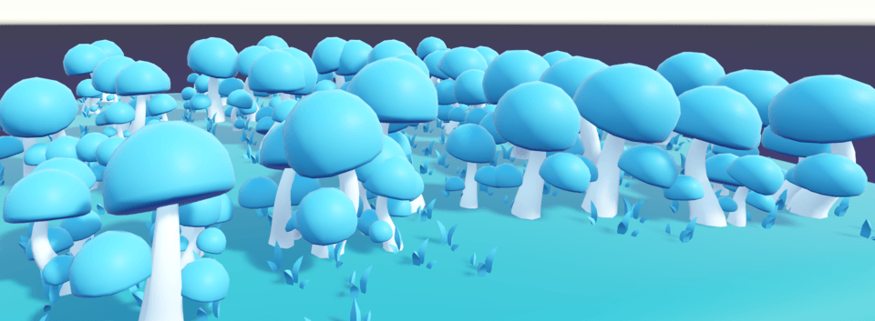

Setting up a `MultiMeshInstance` differs from setting up a `MeshInstance`. The `MultiMeshInstance` node is a container for a `MultiMesh` that Godot renders.

A `MultiMeshInstance` is less performance-heavy than creating a similar number of `MeshInstance` nodes. This is useful for environmental details like trees, grass, and rocks.

To start, create a new `MultiMesh` on a `MultiMeshInstance` node via the *Mutltimesh* property.

You need two sibling *MeshInstances*:

1. The `Mesh` you want to be repeated across your surface. In this case, it would be the tree.
2. The surface you want to be covered by the trees. In this example, select a flat plane.

[figure not shown]

From here, you can set up the `MultiMesh` either through a dialog in the editor or via a script. The dialog lets you populate a surface with a mesh in a few clicks but lacks finer control. Using a script to adjust the `MultiMesh` provides more freedom but is more work.

#### The MultiMesh Populate Surface dialog

With the `MultiMeshInstance` node selected, navigate to the top bar on the editor and select `MultiMesh`, then *Populate Surface*.

[figure not shown]

This opens a new window with several options. *Target Surface* is the `NodePath` to the `MeshInstance` that you want to cover in the *Source Mesh*. *Source Mesh* is the `NodePath` to the `MeshInstance` to be randomly distributed. Note that this is not a `Mesh`, but an actual `MeshInstance` node in the scene.

Clicking the button with two dots on the right of the textbox lets you select *Nodes* in your scene tree to select the `NodePath`.

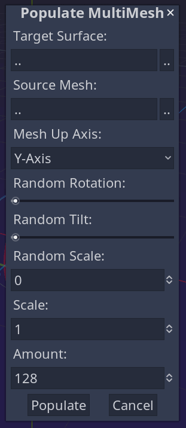

Set a `MeshInstance` of a tree as the *Source Mesh* and a `PlaneMesh` as the *Target Surface*. You can adjust the *Random Rotation, Random Tilt, Random Scale,* and *Scale* settings to rotate, tilt and scale the trees. The *Amount* setting controls the amount of trees that will be in the scene. When you are finished adjusting your settings, click *Populate*.

If your meshes are clipping into each other, try lowering the *Random Tilt, Random Scale,* and *Amount* settings.

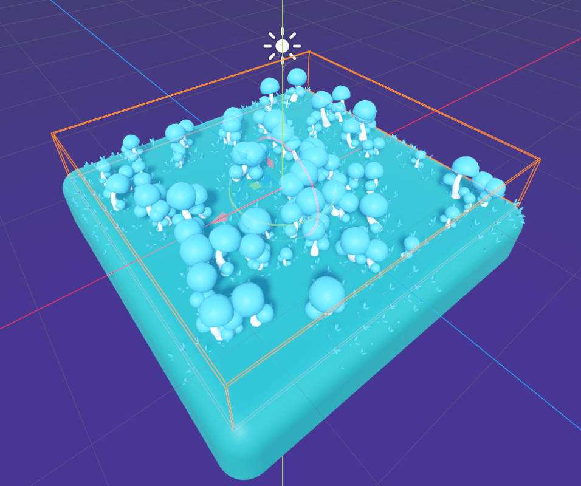

We hid both the `FloorMesh` and `Tree` nodes in the demo files in case you need them to regenerate the `MultiMesh` in the future.

### Creating flocking Boids behavior with a MultiMeshInstance with a script

You may have a scene with a flock of birds, a school of fish, or a crowd of people. You can improve performance by making them all part of a `MultiMesh`.

This approach is useful if you want a group of actors in the background that don’t need to collide with the player or directly influence gameplay.

You can use a `MultiMeshInstance` to make a flying school of fish that flocks together within an area.

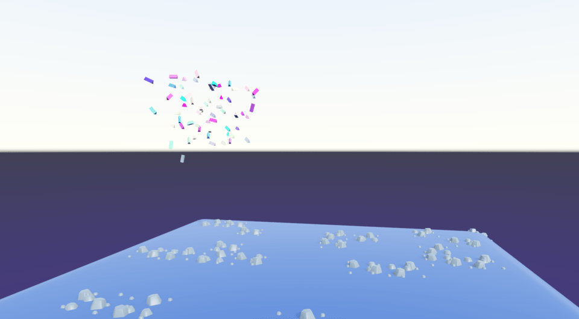

We set up this `MultiMeshInstance` manually through code, as we want to keep track of each fish individually.

Each `MultiMesh` has a *Transform Format* property that sets a flag for using 2D or 3D transforms. The *Boids* demo uses the *3D* option since each boid can move on three axes. To control each instance’s 3D `Transform`, we use the `set_instance_transform()` function on the `MultiMesh`.

*Color Format* controls how compressed the color data is. Use *Float* for the highest precision since there are only `60` instances. Setting *Color Format* to *Byte* decreases the memory required to run the scene but causes some loss in precision.

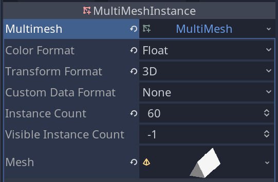

The `_ready()` function gives each fish a random color and starting position within a bounding box. This function also stores important information about each fish in an array. This fish data structure holds its transform, index, and direction values.

When dealing with a `MultiMesh`, you can access every `Mesh` individually by its index. You can use this index to update an individual mesh’s properties.

```
func _ready() -> void:
    randomize()
    for index in multimesh.instance_count:
        # We calculate a random position and direction at which each fish starts.
        var start_position := Vector3(
            rand_range(bounding_box.position.x, bounding_box.end.x),
            rand_range(bounding_box.position.y, bounding_box.end.y),
            rand_range(bounding_box.position.z, bounding_box.end.z)
        )
        var starting_transform := Transform(Basis(), start_position)
        var starting_direction := Vector3(rand_range(-1, 1), rand_range(-1, 1), rand_range(-1, 1)).normalized()
        # We store each fish in an array to keep track of the starting transform
        # and move direction.
        _fish.append(Fish.new(starting_transform, starting_direction, index))
        # We initialize the fishes' starting positions and colors.
        multimesh.set_instance_transform(index, starting_transform)
        multimesh.set_instance_color(index, Color(randf(), randf(), 0.5))
```

Boids is the name given to a model for groups of animals like birds or fish moving in unison. The model encompasses three basic behaviors that come together to simulate a flock.

The three behaviors are:

1. Separation - each boid steers away from the others to avoid crashing into them.
2. Alignment - each boid steers toward the average heading of the other boids.
3. Cohesion - each boid steers toward the center of the other boids.

Each of these behaviors is a vector pointing from each boid in a direction. Adding the vectors together with various weights gives the overall direction the boid needs to go.

We exported the weight values for separation, alignments, and cohesion. Exporting them allows you to adjust the behavior of the boids in the demo.

```
export var separation_weight := 0.05
export var alignment_weight := 0.02
export var cohesion_weight := 0.01
export var bound_weight := 0.15
export var fish_speed := 4.0
export var fish_separation_squared := 1.5 * 1.5
export var bounding_box := AABB()
```

Setting any of the three behavior weights (`seperation_weight`, `alignment_weight`, or `cohesion_weight`) to `0` turns off that behavior.

Additionally, we constrained the fish to a `20` x `20` x `10` box area defined by an `AABB` bounding box. The `bound_weight` variable adjusts the rate at which the fish steer back inside the bounding box once they leave.

Usually, boids adjust their trajectory based on those nearby, ignoring those that are too far away. This demo calculates the new direction based on all other boids for simplicity.

```
    # Note this naive implementation has an exponential cost. It works for small
    # clumps of fishes but will become heavy for very large flocks.
    #
    # You can partition the fishes in a grid and only take nearby fishes into
    # account if you need larger flocks or swarms of boids.
    for fish in _fish:
        if fish != current_fish:
            cohesion += fish.transform.origin
            alignment += fish.direction
            # If a fish is too close to another apply a foce away from the neighbor.
            #
            # Notice the use of distance_squared_to(), which is faster than distance_to().
            if (
                fish.transform.origin.distance_squared_to(current_fish.transform.origin)
                < fish_separation_squared
            ):
                separation -= fish.transform.origin - current_fish.transform.origin

    # Calculate mean cohesion and alignment.
    cohesion = cohesion / (_fish.size() - 1.0)
    alignment = alignment / (_fish.size() - 1.0)

    # Combine path forces with weights.
    cohesion = (cohesion - current_fish.transform.origin) * cohesion_weight
    alignment = (alignment - current_fish.direction) * alignment_weight
    separation *= separation_weight
    # If a fish is outside the bounding box, we apply a force towards the center.
    if not bounding_box.has_point(current_fish.transform.origin):
        bounding_force = -current_fish.transform.origin * bound_weight

    return cohesion + alignment + separation + bounding_force
```

```
    # Every frame, we find the path for each fish and move them in that direction.
    for current_fish in _fish:
        var move_direction := _calculate_boid_direction(current_fish)
        current_fish.direction = (current_fish.direction + move_direction).normalized()
        # We orient the fish to look in the direction of travel.
        current_fish.transform = current_fish.transform.looking_at(
            current_fish.transform.origin + current_fish.direction, Vector3.UP
        )
        current_fish.transform.origin += current_fish.direction * fish_speed * delta
        # Here we upload new transform data to the multimesh object.
        multimesh.set_instance_transform(current_fish.index, current_fish.transform)
```

Once Godot has calculated each fish’s new direction, it is then combined with the current direction by adding it and normalizing the result. You can use `set_instance_transform()` to then move each instance in its calculated direction.

### Changing the shape of your Mesh with a vertex shader

Altering the vertices of a mesh with a shader is an essential skill. Shaders allow for such effects as creating a mountainous horizon or creating rivers and other bodies of water.

In this section, you will use a simple shader to customize the shape of a plane based on a noise texture. The material you learn here will help you to make other effects such as water shaders and low poly horizons.

There are a few steps necessary to add your shader:

1. Create a `MeshInstance` node. Set its *Mesh* property to a new `PlaneMesh` and set its size to `50` by `50`. Now set both the *Subdivide Width* and *Subdivide Height* of the `PlaneMesh` to `10`.
2. Click the *Material* property of the `MeshInstance` created in step 1 to add a new `ShaderMaterial`.
3. Click the newly created `ShaderMaterial` to open its properties. Click on its *Shader* property and add a new `Shader`.

Adding the `Shader` to the *Shader* property and then clicking on it opens the *Shader* code editor in the console at the bottom of the main editor. Here you input shader code in the *Godot shader language* (*GDSL*). *GDSL* is like the *C programming language* and lets you run code on your graphics card. Put the following *GDSL* code into the *Shader* code editor.

```
shader_type spatial;

// The uniform keyword exposes the variable to the editor and GDScript
uniform float scale = 3.0;
uniform sampler2D noise;
```

The first line sets the `shader_type` to *spatial* so that Godot knows the shader is for a 3D environment. The next two lines create the properties `scale` and `noise`. The `noise` property is a texture used as a heightmap to control your plane.

**Note:** In GDSL, you must define the types of your variables. In the above code, scale has type `float` and noise has type `sampler2D`. A `sampler2D` is a texture where you can sample values.

It is typical to use textures as instructions for your shader code. A noise texture varies from black to white semi-randomly. This texture tells your shader where to move the plane up and down.

Click on the `MeshInstance` node you attached the shader code to.

1. Add a new `NoiseTexture` to the *Mesh* -> *Material* -> *Shader Param* -> *Noise* property.

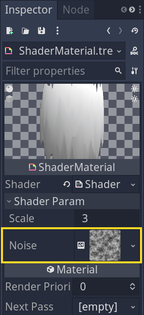

2. On the newly created `NoiseTexture`, set the *Noise* property to a new `OpenSimplexNoise`.

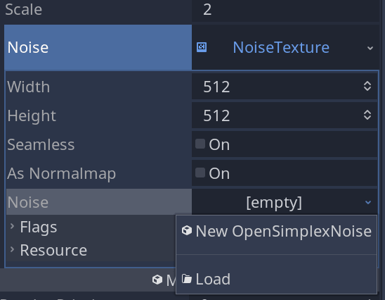

The shader code will shift the vertices up and down based on the provided noise texture. It will also adds a small amount of coloring to make the bumps more visible. You can do all this with two functions:

- The `vertex()` function, which handles the position of all the vertices.
- The `fragment()` function, which handles the for coloring the fragment of the object visible.

Add the following code to the `Shader` attached your `MeshInstance` node. If your *Shader* code editor is gone, you may find it by clicking on the *Mesh* -> *Material* -> *Shader* property of your `MeshInstance` node.

```
void vertex() {
  vec2 position = VERTEX.xz;
  // Return a value between 0.0 and 1.0 for the corresponding spot on the noise texture.
  float height = texture(noise, position).x;
  // Save this vlaue as a grayscale color for the fragment to use.
  COLOR.rgb = vec3(height);
  // Offset the height of each vertex proportionally to the noise texture
  VERTEX.y += (height - 0.5) * scale;
}

void fragment() {
  ALBEDO = COLOR.rgb;
}
```

Now duplicate your `MeshInstance` node and move it in the editor so you can see both planes. Click the *Mesh* property and select *Make Unique*.

Try changing the *Mesh* -> *Subdivide Width* and *Subdivide Height* properties to see their effect. As those values increase, the number of vertices the `vertex()` function applies to increases. Adding vertices to your mesh increases its level of detail.

In the below image the left most plane has much less detail than the third because it has over forty times fewer vertices.

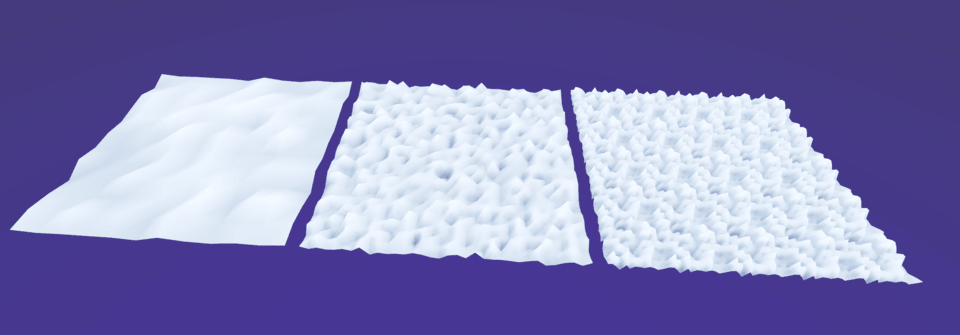

## Pro tips

### Generating collision bodies

In a typical workflow you import and add some meshes produced in a 3D modeling program. You then need to create a static, rigid, or kinematic body for them. Godot has many functions to help speed up this process.

Select a `MeshInstance` node and then click on the *Mesh* button at the top of 3D editor viewport.

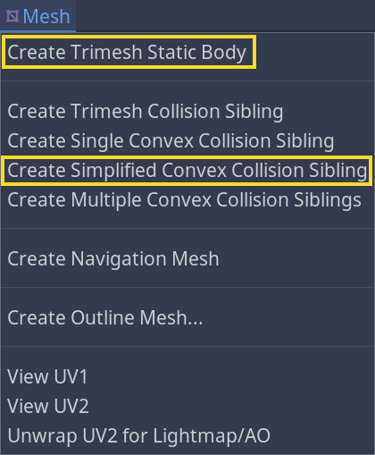

### Creating other resources from meshes

The *Mesh* button at the top of 3D editor viewport also lets you generate a few other very helpful nodes.

You can *Create Navigation Mesh*. For more information, take a look at our Navigation guide.

Or, you can *Create Outline Mesh…* by setting a size around the original shape. This option is a useful when showing an object selected in-game. But the outline isn’t perfect and artifacts can occur on complex shapes. We cover making nicer outlines with an animation in the AnimationPlayer guide.

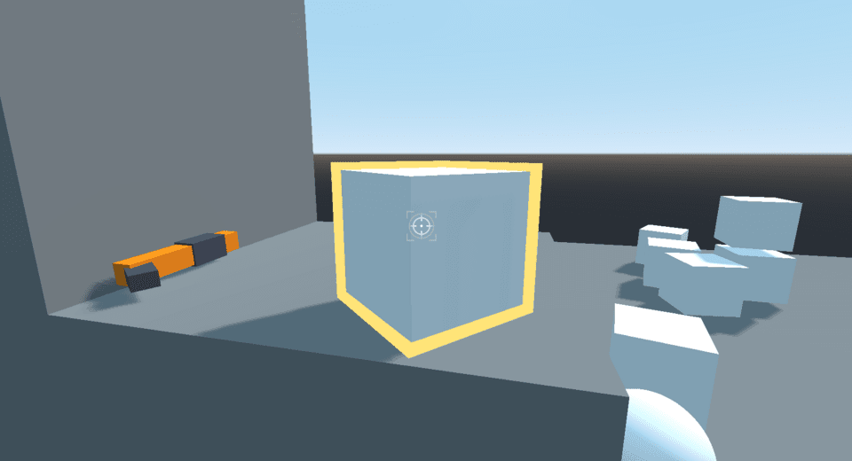

## Your questions

### When should I use MultiMeshInstances instead of MeshInstances?

The main benefit of a `MultiMeshInstance` is the low-cost rendering of repeated meshes. However, it is often harder to get complex behavior out of each instance. For example, `MultiMeshInstance` does not support adding collision shapes to each `Mesh`. But you can script such behavior yourself. One way is to use the `Shape` returned from the `MultiMesh.mesh.create_trimesh_shape()` function as the `CollisionShape`.

`MultiMeshInstance` is the most practical way to fill a field with lots of repeated grass or other objects without collision. Most other level props that need collision or other unique behaviors should use `MeshInstance` nodes. You can extend these with `CollisionShapes` and scripts for more control over behavior.